# FinalProject_Notebook

```python
# General Description and data cleaning of bold dataset
import pandas as pd
import numpy as np
import matplotlib.pyplot as plt
import seaborn as sns
```

```python
import warnings
warnings.filterwarnings("ignore")
```

```python
# Set display options for better visibility
pd.set_option('display.max_columns', None)
pd.set_option('display.max_rows', 100)
```

```python
bold_df = pd.read_csv('bold_dataset.csv', low_memory = False)
```

```python
bold_df.head(5)
```

|  | unique_subject_id | unique_hospital_admission_id | unique_icustay_id | subject_id | hospital_admission_id | icustay_id | source_db | hospitalid | numbedscategory | teachingstatus | region | admission_age | sex_female | weight_admission | height_admission | BMI_admission | datetime_hospital_admit | datetime_hospital_discharge | datetime_icu_admit | datetime_icu_discharge | los_hospital | los_ICU | comorbidity_score_name | comorbidity_score_value | in_hospital_mortality | race_ethnicity | SaO2_timestamp | pH | pCO2 | … |
| --- | --- | --- | --- | --- | --- | --- | --- | --- | --- | --- | --- | --- | --- | --- | --- | --- | --- | --- | --- | --- | --- | --- | --- | --- | --- | --- | --- | --- | --- | --- |
| 0 | 0.0 | 0.0 | 0.0 | 002-10050 | 183274.0 | 211144.0 | eicu | 71.0 | 100 - 249 | False | Midwest | 67.0 | 1.0 | 86.2 | 160.0 | 33.671875 | 2013-12-31 22:53:00 | 2014-01-07 17:37:00 | 2014-01-01 0:00:00 | 2014-01-04 20:19:00 | 6.780556 | 3.833333 | Charlson | 3.0 | 0.0 | White | 2014-01-01 0:35:00 | 7.25 | 55.0 | … |
| 1 | 1.0 | 1.0 | 1.0 | 002-1007 | 178462.0 | 204935.0 | eicu | 71.0 | 100 - 249 | False | Midwest | 83.0 | 1.0 | NaN | 162.6 | NaN | 2013-12-30 12:04:00 | 2014-01-02 2:33:00 | 2014-01-01 0:00:00 | 2014-01-01 12:03:00 | 2.603472 | 0.500000 | Charlson | 9.0 | 1.0 | White | 2014-01-01 5:14:00 | 7.31 | 32.0 | … |
| 2 | 2.0 | 2.0 | 2.0 | 002-10187 | 150828.0 | 169525.0 | eicu | 73.0 | >= 500 | True | Midwest | 59.0 | 1.0 | 74.1 | 162.6 | 28.027033 | 2013-12-31 23:46:00 | 2014-01-04 0:14:00 | 2014-01-01 0:00:00 | 2014-01-03 0:15:00 | 3.019444 | 2.000000 | Charlson | 2.0 | 0.0 | White | 2014-01-01 0:13:00 | 7.33 | 48.0 | … |
| 3 | 3.0 | 3.0 | 3.0 | 002-10306 | 198249.0 | 230427.0 | eicu | 63.0 | 100 - 249 | False | Midwest | 73.0 | 0.0 | NaN | 152.4 | NaN | 2013-12-31 22:49:00 | 2014-01-08 17:31:00 | 2014-01-01 0:00:00 | 2014-01-07 6:57:00 | 7.779167 | 6.291667 | Charlson | 4.0 | 0.0 | Asian | 2014-01-03 20:53:00 | 7.36 | 40.0 | … |
| 4 | 4.0 | 4.0 | 4.0 | 002-10324 | 188445.0 | 217835.0 | eicu | 73.0 | >= 500 | True | Midwest | 57.0 | 0.0 | NaN | 172.7 | NaN | 2013-12-29 23:23:00 | 2014-01-06 15:33:00 | 2014-01-01 0:00:00 | 2014-01-04 6:39:00 | 7.673611 | 3.291667 | Charlson | 1.0 | 0.0 | White | 2014-01-01 0:23:00 | 7.31 | 55.0 | … |

```python
bold_df.columns
```

```
Index(['unique_subject_id', 'unique_hospital_admission_id',
       'unique_icustay_id', 'subject_id', 'hospital_admission_id',
       'icustay_id', 'source_db', 'hospitalid', 'numbedscategory',
       'teachingstatus',
       ...
       'delta_sofa_future_liver_24hr', 'sofa_future_liver_24hr',
       'delta_sofa_future_cardiovascular_24hr',
       'sofa_future_cardiovascular_24hr', 'delta_sofa_future_cns_24hr',
       'sofa_future_cns_24hr', 'delta_sofa_future_renal_24hr',
       'sofa_future_renal_24hr', 'Unnamed: 142', 'Unnamed: 143'],
      dtype='object', length=144)
```

```python
# shape
print(f"The Number of Rows are {bold_df.shape[0]}, and columns are {bold_df.shape[1]}.")
```

```
The Number of Rows are 49095, and columns are 144.
```

```python
# columns with dtype
bold_df.dtypes
```

```
unique_subject_id               float64
unique_hospital_admission_id    float64
unique_icustay_id               float64
subject_id                       object
hospital_admission_id           float64
                                 ...
sofa_future_cns_24hr            float64
delta_sofa_future_renal_24hr    float64
sofa_future_renal_24hr          float64
Unnamed: 142                    float64
Unnamed: 143                    float64
Length: 144, dtype: object
```

```python
# null values
bold_df.isnull().sum()
```

```
unique_subject_id                   2
unique_hospital_admission_id        2
unique_icustay_id                   2
subject_id                          2
hospital_admission_id               2
                                ...
sofa_future_cns_24hr             9428
delta_sofa_future_renal_24hr     9428
sofa_future_renal_24hr           9428
Unnamed: 142                    49095
Unnamed: 143                    49095
Length: 144, dtype: int64
```

```python
# cut before SpO2
columns = list(bold_df.columns)
index_of_spo2 = columns.index('SpO2')
new_bold_df = bold_df.iloc[:, :index_of_spo2 + 1]
```

```python
new_bold_df.head()
```

|  | unique_subject_id | unique_hospital_admission_id | unique_icustay_id | subject_id | hospital_admission_id | icustay_id | source_db | hospitalid | numbedscategory | teachingstatus | region | admission_age | sex_female | weight_admission | height_admission | BMI_admission | datetime_hospital_admit | datetime_hospital_discharge | datetime_icu_admit | datetime_icu_discharge | los_hospital | los_ICU | comorbidity_score_name | comorbidity_score_value | in_hospital_mortality | race_ethnicity | SaO2_timestamp | pH | pCO2 | … |
| --- | --- | --- | --- | --- | --- | --- | --- | --- | --- | --- | --- | --- | --- | --- | --- | --- | --- | --- | --- | --- | --- | --- | --- | --- | --- | --- | --- | --- | --- | --- |
| 0 | 0.0 | 0.0 | 0.0 | 002-10050 | 183274.0 | 211144.0 | eicu | 71.0 | 100 - 249 | False | Midwest | 67.0 | 1.0 | 86.2 | 160.0 | 33.671875 | 2013-12-31 22:53:00 | 2014-01-07 17:37:00 | 2014-01-01 0:00:00 | 2014-01-04 20:19:00 | 6.780556 | 3.833333 | Charlson | 3.0 | 0.0 | White | 2014-01-01 0:35:00 | 7.25 | 55.0 | … |
| 1 | 1.0 | 1.0 | 1.0 | 002-1007 | 178462.0 | 204935.0 | eicu | 71.0 | 100 - 249 | False | Midwest | 83.0 | 1.0 | NaN | 162.6 | NaN | 2013-12-30 12:04:00 | 2014-01-02 2:33:00 | 2014-01-01 0:00:00 | 2014-01-01 12:03:00 | 2.603472 | 0.500000 | Charlson | 9.0 | 1.0 | White | 2014-01-01 5:14:00 | 7.31 | 32.0 | … |
| 2 | 2.0 | 2.0 | 2.0 | 002-10187 | 150828.0 | 169525.0 | eicu | 73.0 | >= 500 | True | Midwest | 59.0 | 1.0 | 74.1 | 162.6 | 28.027033 | 2013-12-31 23:46:00 | 2014-01-04 0:14:00 | 2014-01-01 0:00:00 | 2014-01-03 0:15:00 | 3.019444 | 2.000000 | Charlson | 2.0 | 0.0 | White | 2014-01-01 0:13:00 | 7.33 | 48.0 | … |
| 3 | 3.0 | 3.0 | 3.0 | 002-10306 | 198249.0 | 230427.0 | eicu | 63.0 | 100 - 249 | False | Midwest | 73.0 | 0.0 | NaN | 152.4 | NaN | 2013-12-31 22:49:00 | 2014-01-08 17:31:00 | 2014-01-01 0:00:00 | 2014-01-07 6:57:00 | 7.779167 | 6.291667 | Charlson | 4.0 | 0.0 | Asian | 2014-01-03 20:53:00 | 7.36 | 40.0 | … |
| 4 | 4.0 | 4.0 | 4.0 | 002-10324 | 188445.0 | 217835.0 | eicu | 73.0 | >= 500 | True | Midwest | 57.0 | 0.0 | NaN | 172.7 | NaN | 2013-12-29 23:23:00 | 2014-01-06 15:33:00 | 2014-01-01 0:00:00 | 2014-01-04 6:39:00 | 7.673611 | 3.291667 | Charlson | 1.0 | 0.0 | White | 2014-01-01 0:23:00 | 7.31 | 55.0 | … |

```python
new_bold_df.describe()
```

|  | unique_subject_id | unique_hospital_admission_id | unique_icustay_id | hospital_admission_id | icustay_id | hospitalid | admission_age | sex_female | weight_admission | height_admission | BMI_admission | los_hospital | los_ICU | comorbidity_score_value | in_hospital_mortality | pH | pCO2 | pO2 | SaO2 | SpO2 |
| --- | --- | --- | --- | --- | --- | --- | --- | --- | --- | --- | --- | --- | --- | --- | --- | --- | --- | --- | --- | --- |
| count | 49093.000000 | 49093.000000 | 49093.000000 | 4.909300e+04 | 4.909300e+04 | 49093.000000 | 49091.000000 | 49093.000000 | 47989.000000 | 47809.000000 | 47108.000000 | 49093.000000 | 49093.000000 | 49091.000000 | 48689.000000 | 49093.000000 | 49093.000000 | 49093.000000 | 49093.000000 | 49093.000000 |
| mean | 22321.346770 | 24546.000000 | 24546.000000 | 3.714965e+06 | 5.042749e+06 | 1390.338867 | 64.429549 | 0.436580 | 85.611319 | 169.347372 | 200.285514 | 11.547233 | 5.226004 | 4.217453 | 0.175440 | 7.524186 | 42.516932 | 127.245993 | 95.917711 | 97.137066 |
| std | 12867.699928 | 14172.072719 | 14172.072719 | 7.188941e+06 | 1.009687e+07 | 3107.897108 | 15.800227 | 0.495967 | 27.847338 | 12.872780 | 8189.044538 | 13.662529 | 7.130980 | 3.044719 | 0.380347 | 33.569718 | 13.696358 | 81.867212 | 4.180759 | 3.834850 |
| min | 0.000000 | 0.000000 | 0.000000 | 1.000680e+05 | 1.412330e+05 | 59.000000 | 14.000000 | 0.000000 | 0.000000 | 0.000000 | 0.000000 | -0.264583 | 0.000000 | -15.000000 | 0.000000 | 6.503000 | 0.000000 | 9.000000 | 70.000000 | 70.000000 |
| 25% | 11127.000000 | 12273.000000 | 12273.000000 | 7.178640e+05 | 9.740030e+05 | 188.000000 | 55.000000 | 0.000000 | 67.400000 | 162.560000 | 23.824857 | 4.889583 | 1.666667 | 2.000000 | 0.000000 | 7.310000 | 34.000000 | 76.000000 | 94.600000 | 96.000000 |
| 50% | 22383.000000 | 24546.000000 | 24546.000000 | 1.286911e+06 | 1.653949e+06 | 264.000000 | 66.000000 | 0.000000 | 81.500000 | 170.000000 | 28.058219 | 8.128472 | 3.041667 | 4.000000 | 0.000000 | 7.370000 | 40.000000 | 100.000000 | 97.000000 | 98.000000 |
| 75% | 33416.000000 | 36819.000000 | 36819.000000 | 2.443592e+06 | 3.014838e+06 | 417.000000 | 76.000000 | 1.000000 | 99.000000 | 177.800000 | 33.564014 | 14.124306 | 6.125000 | 6.000000 | 0.000000 | 7.420000 | 47.000000 | 146.000000 | 99.000000 | 100.000000 |
| max | 44901.000000 | 49092.000000 | 49092.000000 | 2.999550e+07 | 3.999574e+07 | 9999.000000 | 90.000000 | 1.000000 | 771.200000 | 504.800000 | 725551.020400 | 763.455556 | 506.375000 | 41.000000 | 1.000000 | 7410.000000 | 181.700000 | 1143.800000 | 100.000000 | 100.000000 |

```python
new_bold_df.isnull().sum()
```

```
unique_subject_id                  2
unique_hospital_admission_id       2
unique_icustay_id                  2
subject_id                         2
hospital_admission_id              2
icustay_id                         2
source_db                          2
hospitalid                         2
numbedscategory                 3927
teachingstatus                     2
region                          2977
admission_age                      4
sex_female                         2
weight_admission                1106
height_admission                1286
BMI_admission                   1987
datetime_hospital_admit            2
datetime_hospital_discharge        2
datetime_icu_admit                 2
datetime_icu_discharge             2
los_hospital                       2
los_ICU                            2
comorbidity_score_name             2
comorbidity_score_value            4
in_hospital_mortality            406
race_ethnicity                     2
SaO2_timestamp                     2
pH                                 2
pCO2                               2
pO2                                2
SaO2                               2
SpO2                               2
dtype: int64
```

```python
new_bold_df_cleaned = new_bold_df.dropna()
```

```python
new_bold_df_cleaned.isnull().sum()
```

```
unique_subject_id               0
unique_hospital_admission_id    0
unique_icustay_id               0
subject_id                      0
hospital_admission_id           0
icustay_id                      0
source_db                       0
hospitalid                      0
numbedscategory                 0
teachingstatus                  0
region                          0
admission_age                   0
sex_female                      0
weight_admission                0
height_admission                0
BMI_admission                   0
datetime_hospital_admit         0
datetime_hospital_discharge     0
datetime_icu_admit              0
datetime_icu_discharge          0
los_hospital                    0
los_ICU                         0
comorbidity_score_name          0
comorbidity_score_value         0
in_hospital_mortality           0
race_ethnicity                  0
SaO2_timestamp                  0
pH                              0
pCO2                            0
pO2                             0
SaO2                            0
SpO2                            0
dtype: int64
```

```python
new_bold_df_cleaned.head()
```

|  | unique_subject_id | unique_hospital_admission_id | unique_icustay_id | subject_id | hospital_admission_id | icustay_id | source_db | hospitalid | numbedscategory | teachingstatus | region | admission_age | sex_female | weight_admission | height_admission | BMI_admission | datetime_hospital_admit | datetime_hospital_discharge | datetime_icu_admit | datetime_icu_discharge | los_hospital | los_ICU | comorbidity_score_name | comorbidity_score_value | in_hospital_mortality | race_ethnicity | SaO2_timestamp | pH | pCO2 | … |
| --- | --- | --- | --- | --- | --- | --- | --- | --- | --- | --- | --- | --- | --- | --- | --- | --- | --- | --- | --- | --- | --- | --- | --- | --- | --- | --- | --- | --- | --- | --- |
| 0 | 0.0 | 0.0 | 0.0 | 002-10050 | 183274.0 | 211144.0 | eicu | 71.0 | 100 - 249 | False | Midwest | 67.0 | 1.0 | 86.2 | 160.0 | 33.671875 | 2013-12-31 22:53:00 | 2014-01-07 17:37:00 | 2014-01-01 0:00:00 | 2014-01-04 20:19:00 | 6.780556 | 3.833333 | Charlson | 3.0 | 0.0 | White | 2014-01-01 0:35:00 | 7.25 | 55.0 | … |
| 2 | 2.0 | 2.0 | 2.0 | 002-10187 | 150828.0 | 169525.0 | eicu | 73.0 | >= 500 | True | Midwest | 59.0 | 1.0 | 74.1 | 162.6 | 28.027033 | 2013-12-31 23:46:00 | 2014-01-04 0:14:00 | 2014-01-01 0:00:00 | 2014-01-03 0:15:00 | 3.019444 | 2.000000 | Charlson | 2.0 | 0.0 | White | 2014-01-01 0:13:00 | 7.33 | 48.0 | … |
| 5 | 5.0 | 5.0 | 5.0 | 002-10328 | 146107.0 | 163413.0 | eicu | 73.0 | >= 500 | True | Midwest | 59.0 | 0.0 | 116.7 | 175.3 | 37.975808 | 2013-12-31 23:57:00 | 2014-01-08 1:07:00 | 2014-01-01 0:00:00 | 2014-01-03 5:35:00 | 7.048611 | 2.250000 | Charlson | 2.0 | 0.0 | White | 2014-01-01 0:10:00 | 7.31 | 56.0 | … |
| 6 | 6.0 | 6.0 | 6.0 | 002-10444 | 140372.0 | 155956.0 | eicu | 73.0 | >= 500 | True | Midwest | 63.0 | 1.0 | 60.2 | 149.9 | 26.791265 | 2013-12-31 23:58:00 | 2014-01-10 7:41:00 | 2014-01-01 0:00:00 | 2014-01-03 19:35:00 | 9.321528 | 2.833333 | Charlson | 3.0 | 0.0 | White | 2014-01-01 0:14:00 | 7.30 | 52.0 | … |
| 7 | 7.0 | 7.0 | 7.0 | 002-10445 | 133572.0 | 147176.0 | eicu | 73.0 | >= 500 | True | Midwest | 63.0 | 1.0 | 84.8 | 154.9 | 35.342154 | 2013-12-31 23:43:00 | 2014-01-09 3:31:00 | 2014-01-01 0:00:00 | 2014-01-05 3:24:00 | 8.158333 | 4.125000 | Charlson | 3.0 | 0.0 | White | 2014-01-01 0:15:00 | 7.33 | 46.0 | … |

```python
print(f"The Number of Rows are {new_bold_df_cleaned.shape[0]}, and columns are {new_bold_df_cleaned.shape[1]}.")
```

```
The Number of Rows are 41540, and columns are 32.
```

```python
# number of row and column eliminated
original_shape = bold_df.shape
cleaned_shape = new_bold_df_cleaned.shape
rows_eliminated = original_shape[0] - cleaned_shape[0]
columns_eliminated = original_shape[1] - cleaned_shape[1]
print(f"Rows Eliminated: {rows_eliminated}, Columns Eliminated: {columns_eliminated}")
```

[output not shown]

```python
# description for certain columns
# numbedscategory
new_bold_df_cleaned['numbedscategory'].value_counts()
```

```
numbedscategory
>= 500       23885
250 - 499     9116
100 - 249     7023
<100          1516
Name: count, dtype: int64
```

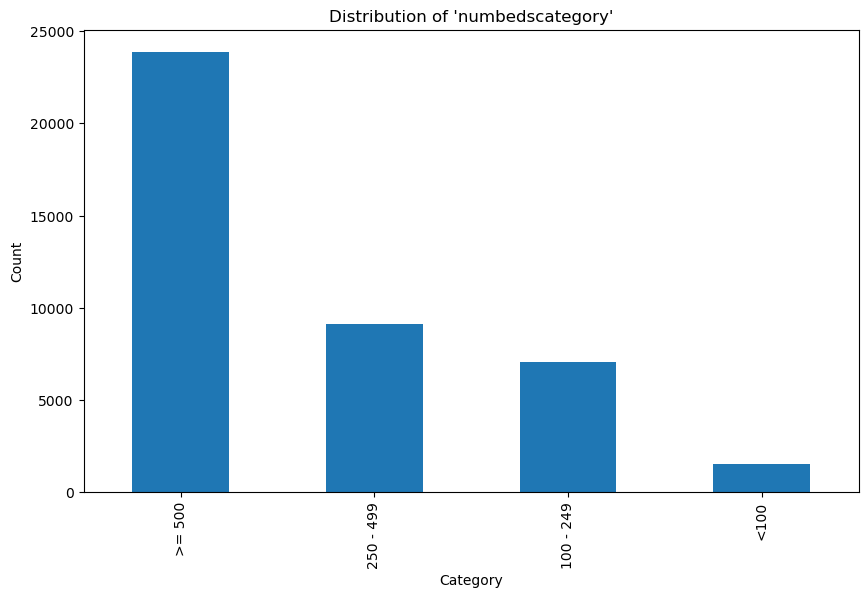

```python
numbedscategory_counts = new_bold_df_cleaned['numbedscategory'].value_counts()
numbedscategory_counts.plot(kind='bar', figsize=(10, 6))
plt.title("Distribution of 'numbedscategory'")
plt.xlabel("Category")
plt.ylabel("Count")
plt.show()
```

```python
# teachingstatus
new_bold_df_cleaned['teachingstatus'].value_counts()
```

```
teachingstatus
False    24131
True     17409
Name: count, dtype: int64
```

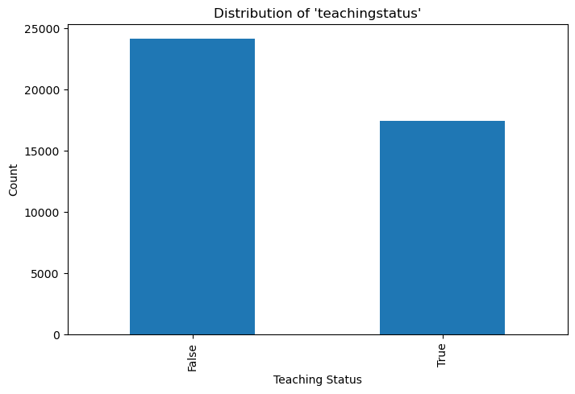

```python
teachingstatus_counts = new_bold_df_cleaned['teachingstatus'].value_counts()
teachingstatus_counts.plot(kind='bar', figsize=(8, 5))
plt.title("Distribution of 'teachingstatus'")
plt.xlabel("Teaching Status")
plt.ylabel("Count")
plt.show()
```

```python
# region
new_bold_df_cleaned['region'].value_counts()
```

```
region
South        12787
Midwest      12191
West          8472
Northeast     8090
Name: count, dtype: int64
```

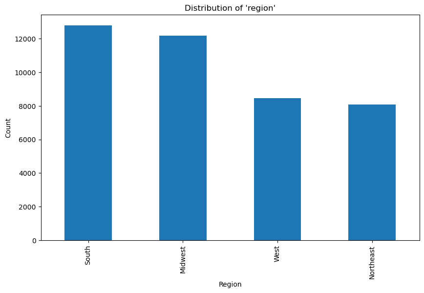

```python
region_counts = new_bold_df_cleaned['region'].value_counts()
region_counts.plot(kind='bar', figsize=(10, 6))
plt.title("Distribution of 'region'")
plt.xlabel("Region")
plt.ylabel("Count")
plt.show()
```

```python
# age
age_bins = [0, 10, 20, 30, 40, 50, 60, 70, 80, 90, 100]
age_labels = ['0-10', '10-20', '20-30', '30-40', '40-50',
              '50-60', '60-70', '70-80', '80-90', '90-100']

new_bold_df_cleaned.loc[:, 'age_category']  = pd.cut(
    new_bold_df_cleaned['admission_age'],
    bins=age_bins,
    labels=age_labels,
    right=False
)

new_bold_df_cleaned['age_category'].value_counts()
```

```
age_category
60-70     10417
70-80      9913
50-60      7400
80-90      6209
40-50      3197
30-40      1796
20-30      1330
90-100     1080
10-20       198
0-10          0
Name: count, dtype: int64
```

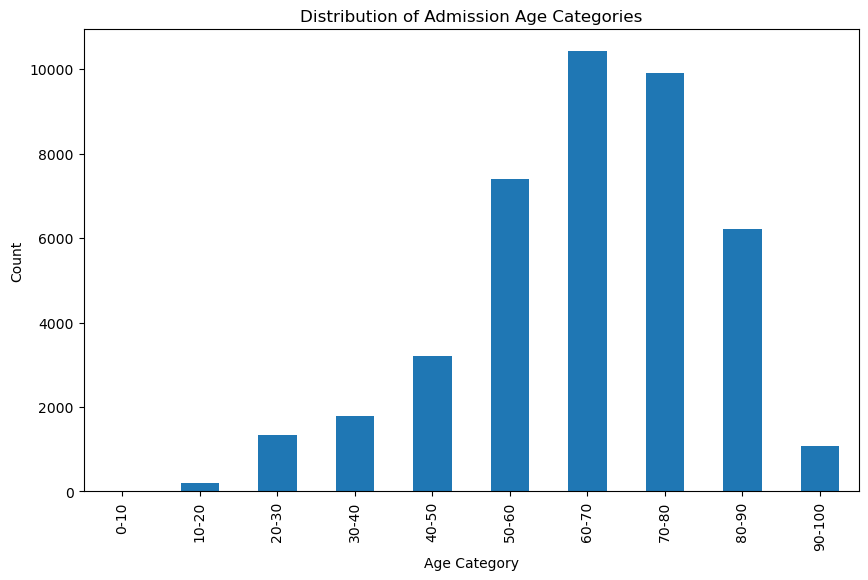

```python
age_category_counts = new_bold_df_cleaned['age_category'].value_counts()
age_category_counts.sort_index().plot(kind='bar', figsize=(10, 6))
plt.title("Distribution of Admission Age Categories")
plt.xlabel("Age Category")
plt.ylabel("Count")
plt.show()
```

```python
new_bold_df_cleaned['admission_age'].describe()
```

```
count    41540.000000
mean        64.442513
std         15.748170
min         14.000000
25%         55.000000
50%         66.000000
75%         76.000000
max         90.000000
Name: admission_age, dtype: float64
```

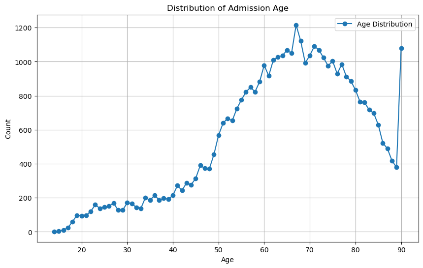

```python
age_distribution = new_bold_df_cleaned['admission_age'].value_counts().sort_index()

plt.figure(figsize=(10, 6))
plt.plot(age_distribution.index, age_distribution.values, marker='o', label='Age Distribution')
plt.title("Distribution of Admission Age")
plt.xlabel("Age")
plt.ylabel("Count")
plt.grid()
plt.legend()
plt.show()
```

```python
# sex
new_bold_df_cleaned['sex_female'].value_counts()
```

```
sex_female
0.0    23439
1.0    18101
Name: count, dtype: int64
```

```python
sex_female_proportions = new_bold_df_cleaned['sex_female'].value_counts(normalize=True) * 100
```

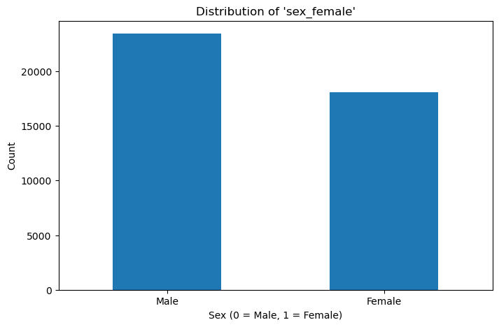

```python
sex_female_counts = new_bold_df_cleaned['sex_female'].value_counts()
sex_female_counts.plot(kind='bar', figsize=(8, 5))
plt.title("Distribution of 'sex_female'")
plt.xlabel("Sex (0 = Male, 1 = Female)")
plt.ylabel("Count")
plt.xticks([0, 1], ['Male', 'Female'], rotation=0)
plt.show()
```

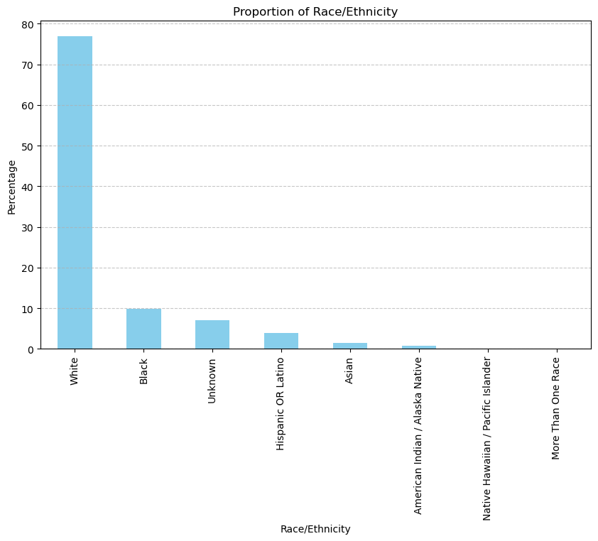

```python
# race
race_ethnicity_counts = new_bold_df_cleaned['race_ethnicity'].value_counts()
race_ethnicity_proportions = race_ethnicity_counts / race_ethnicity_counts.sum() * 100

plt.figure(figsize=(10, 6))
race_ethnicity_proportions.plot(kind='bar', color='skyblue')
plt.title("Proportion of Race/Ethnicity")
plt.ylabel("Percentage")
plt.xlabel("Race/Ethnicity")
plt.grid(axis='y', linestyle='--', alpha=0.7)
plt.show()
```

```python
# Save the cleaned DataFrame to a CSV file
output_file_path = 'new_bold_df_cleaned.csv'
new_bold_df_cleaned.to_csv(output_file_path, index=False)

print(f"DataFrame saved to {output_file_path}")
```

```
DataFrame saved to new_bold_df_cleaned.csv
```

```python
df = new_bold_df_cleaned.copy()
df_sample = df.copy()
```

```python
races_to_drop = ['Native Hawaiian / Pacific Islander', 'More Than One Race']
df = df[~df['race_ethnicity'].isin(races_to_drop)]
df_sample = df_sample[~df_sample['race_ethnicity'].isin(races_to_drop)]
```

## Relative Error Examination

```python
# Calculate relative error
df_sample['Relative Error'] = (df_sample['SpO2'] - df_sample['SaO2']) / df_sample['SaO2']

# Subgroup-specific relative error summary
relative_error_summary = df_sample.groupby('race_ethnicity')['Relative Error'].agg(['mean', 'std']).reset_index()

# Display relative error summary
print("Relative Error Summary by Subgroup:")
relative_error_summary
```

```
Relative Error Summary by Subgroup:
```

|  | race_ethnicity | mean | std |
| --- | --- | --- | --- |
| 0 | American Indian / Alaska Native | 0.016959 | 0.027746 |
| 1 | Asian | 0.016156 | 0.040877 |
| 2 | Black | 0.019943 | 0.052335 |
| 3 | Hispanic OR Latino | 0.015796 | 0.040105 |
| 4 | Unknown | 0.013783 | 0.044702 |
| 5 | White | 0.013280 | 0.043930 |

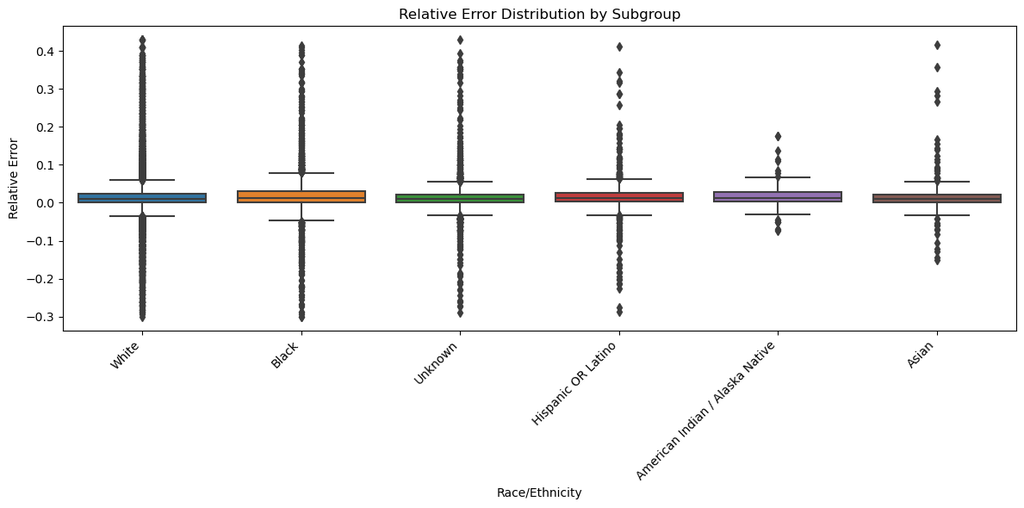

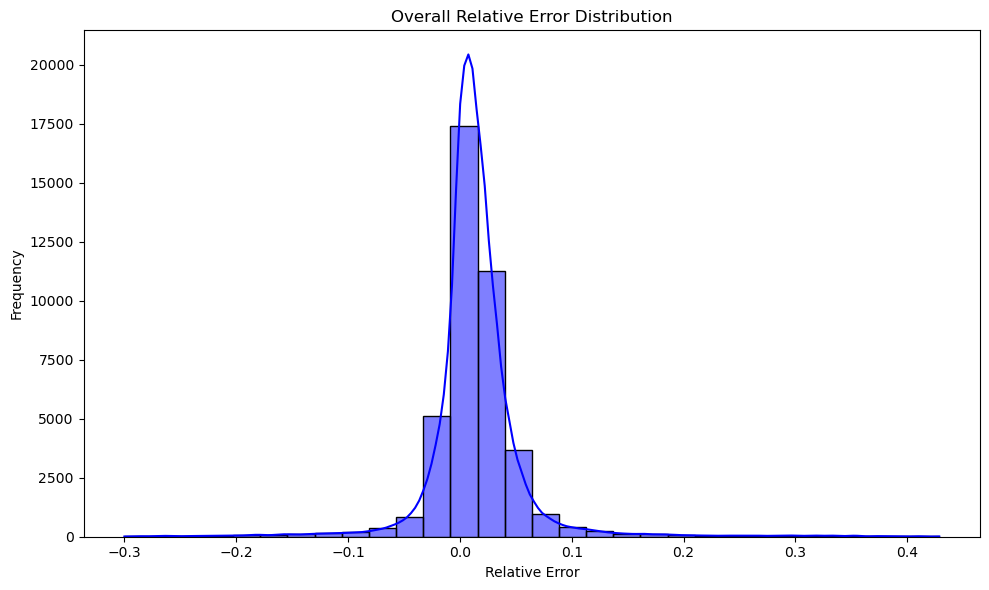

```python
# Boxplot of relative error by subgroup
plt.figure(figsize=(12, 6))
sns.boxplot(x='race_ethnicity', y='Relative Error', data=df_sample)
plt.xticks(rotation=45, ha='right')
plt.title('Relative Error Distribution by Subgroup')
plt.ylabel('Relative Error')
plt.xlabel('Race/Ethnicity')
plt.tight_layout()
plt.show()

# Histogram of overall relative error
plt.figure(figsize=(10, 6))
sns.histplot(df_sample['Relative Error'], kde=True, bins=30, color='blue')
plt.title('Overall Relative Error Distribution')
plt.xlabel('Relative Error')
plt.ylabel('Frequency')
plt.tight_layout()
plt.show()
```

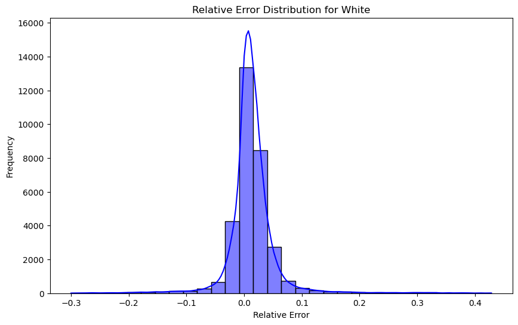

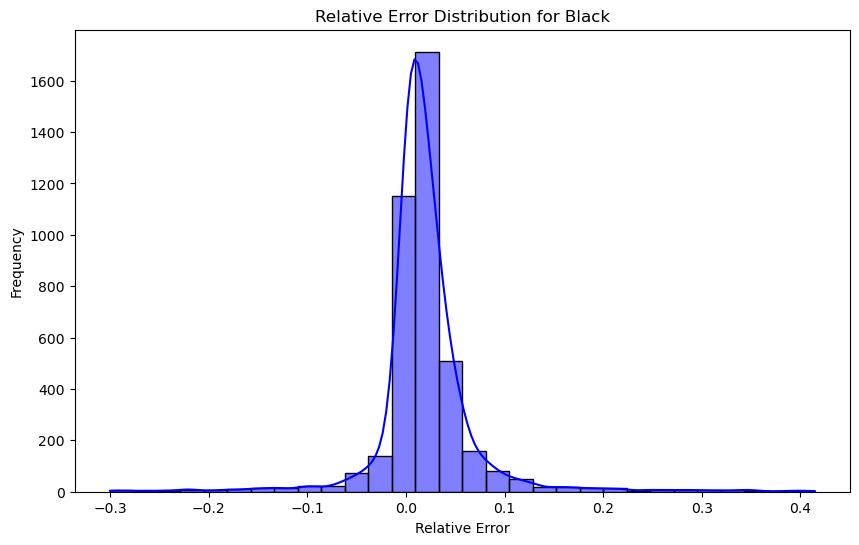

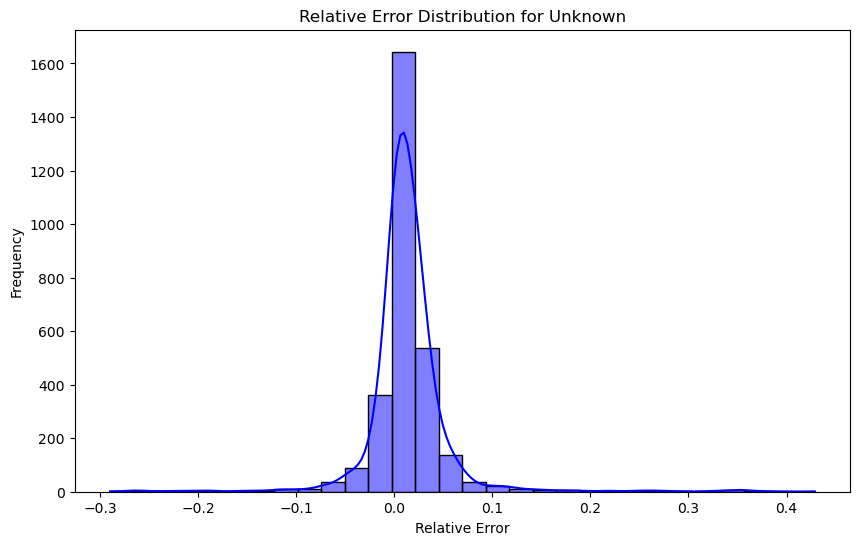

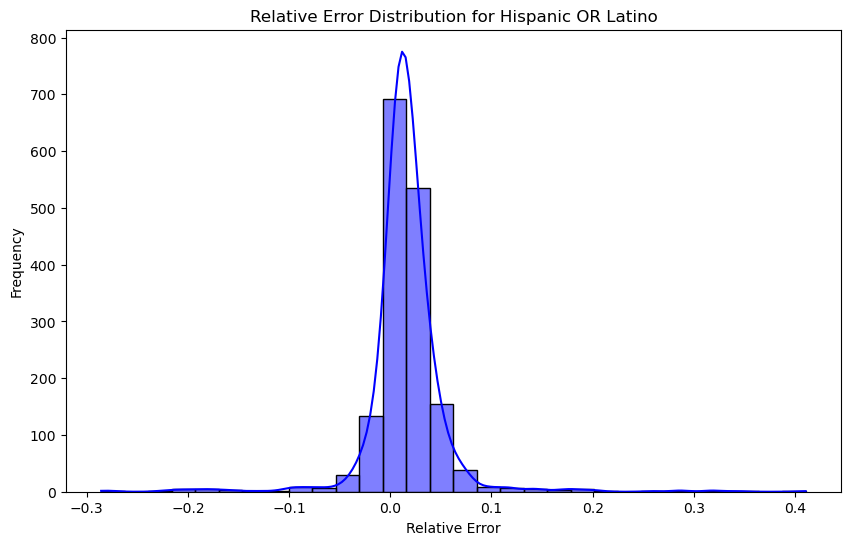

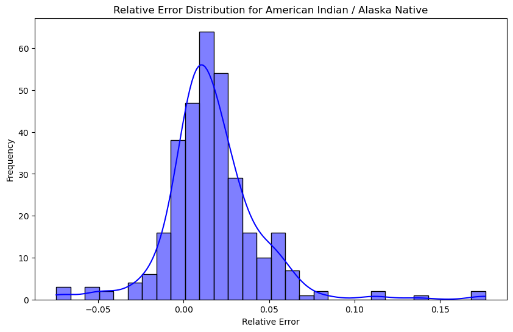

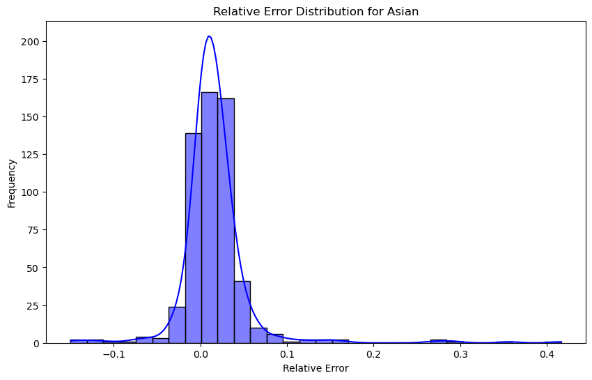

```python
# Unique race/ethnicity groups in the dataset
race_groups = df_sample['race_ethnicity'].unique()

# Generate a histogram for each group
for race in race_groups:
    plt.figure(figsize=(10, 6))
    sns.histplot(
        df_sample[df_sample['race_ethnicity'] == race]['Relative Error'],
        kde=True,
        bins=30,
        color='blue'
    )
    plt.title(f'Relative Error Distribution for {race}')
    plt.xlabel('Relative Error')
    plt.ylabel('Frequency')
    #plt.tight_layout()
    plt.show()
```

## Analysis of Improving ARMS Metric for Racial Bias Minimization

[figure not shown]

Source: AI Wong Lab at Duke University and the BOLD team https://sites.duke.edu/wonglab/

[figure not shown]

Source: AI Wong Lab at Duke University and the BOLD team https://sites.duke.edu/wonglab/

#### Typically, the FDA looks for an ARMS value ~3 in order to qualify a new technology

##### ARMS is the current FDA standard for evaluating pulse oximeter technology. ARMS weights all errors (or residuals) equally whether they are negative or positive, and whether or not they occur in a critical range for missing Hypothermia in patients- which can result in racial bias.

##### We know that pulse oximeter readings have more variability and error rate the greater the amount of melanin in a person's skin- and that we tend to overestimate oxygen levels in patients with darker skin colors leading to the potential of failing to diagnose Hypothermia. A better metric would be more sensitive to whether the error is an overestimation (+) or underestimation (-) of the person's true O2 level.

#### The following two tables present a summary of the functions and weighting mechanisms created and assessed below:

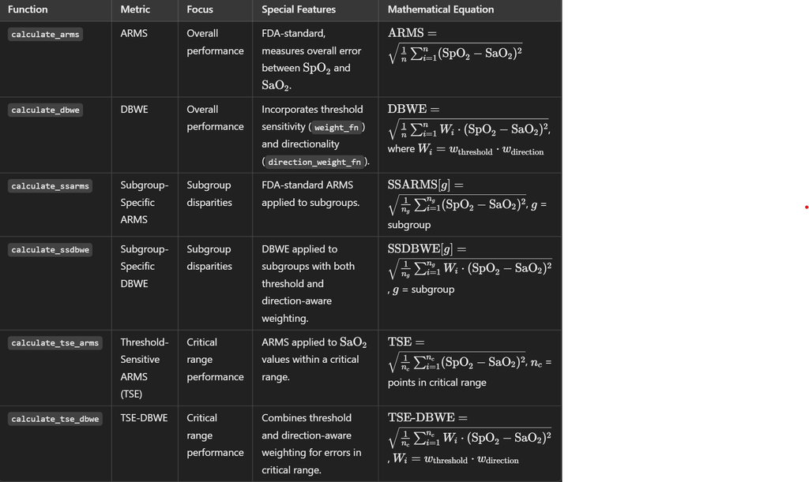

[figure not shown]

Chat-GPT was used to assist in the creating of the above figures, as well as functions, comments, and other code in this section. (Open AI, 2024) https://chatgpt.com/?model=gpt-4o

```python
# Define ARMS calculation. This is the FDA standard
def calculate_arms(df):
    residuals = df['SpO2'] - df['SaO2']
    arms = (residuals ** 2).mean() ** 0.5
    return arms

# Define directional-bias weighted error. Function that combines threshold sensitivity and residual directionality into a weighting coefficient
# that gets multiplied by the standard ARMS summation
def calculate_dbwe(df, weight_fn, direction_weight_fn):
    """
    Calculate Directional Bias-Weighted Error (DBWE) with direction-specific weighting.

    Parameters:
    - df: DataFrame with columns 'SpO2' and 'SaO2'.
    - weight_fn: Function to assign weights based on SaO2 values.
    - direction_weight_fn: Function to assign weights based on the residual direction.

    Returns:
    - DBWE value.
    """
    residuals = df['SpO2'] - df['SaO2']
    base_weights = df['SaO2'].apply(weight_fn)
    direction_weights = residuals.apply(direction_weight_fn)

    # Combine base weights with direction weights
    combined_weights = base_weights * direction_weights

    dbwe = ((combined_weights * (residuals ** 2)).mean()) ** 0.5
    return dbwe

# weighting function to assign a weight of 2 to positive residuals (overestimations of SaO2) and 1 to negative residuals
def direction_weight(residual):
    """
    Assign a weight of 2.0 for positive residuals and 1.0 for negative residuals.
    """
    if residual > 0:
        return 2.0
    return 1.0

# weighting function option to use a centered gaussian distribution to determine weighting. No threshold weighting.
def optimized_weight(sao2, critical_range=(88, 92), peak_weight=2.0, baseline_weight=1.0):
    """
    Assigns dynamic weights to SaO₂ values based on proximity to a critical range.

    Parameters:
    - sao2: The arterial oxygen saturation value.
    - critical_range: A tuple defining the critical range (default is (88, 92)).
    - peak_weight: Maximum weight at the center of the critical range.
    - baseline_weight: Default weight outside the range.

    Returns:
    - A weight value (float).
    """
    lower, upper = critical_range
    mid = (lower + upper) / 2
    span = upper - lower

    # Use a Gaussian function centered at `mid`
    weight = baseline_weight + (peak_weight - baseline_weight) * \
             (1 / (1 + ((sao2 - mid) / (span / 2))**2))

    return weight

# Define a weighting function that emphasizes errors near critical thresholds
def critical_weight(sao2):
    if 88 <= sao2 <= 92:
        return 2.0  # Higher weight for critical range
    return 1.0

# Define Subgroup-Specific ARMS (SSARMS). FDA standard
def calculate_ssarms(df, subgroup_column):
    subgroups = df[subgroup_column].unique()
    ssarms = {}
    for group in subgroups:
        group_data = df[df[subgroup_column] == group]
        ssarms[group] = calculate_arms(group_data)
    return ssarms

# Calculate Threshold-Sensitive Error (TSE) using standard ARMS metric. Works on whole dataset in threshold between 85 and 90% SaO2 readings
def calculate_tse_arms(df, lower=88, upper=92):
    critical_data = df[(df['SaO2'] >= lower) & (df['SaO2'] <= upper)]
    residuals = critical_data['SpO2'] - critical_data['SaO2']
    tse = (residuals ** 2).mean() ** 0.5
    return tse

# Calculate TSE for the whole dataset using directional bias weighted error with threshold sensitivity turned on
def calculate_tse_dbwe(df, weight_fn, direction_weight_fn, lower=88, upper=92):
    """
    Calculate Threshold-Sensitive Error using Directional Bias-Weighted Error (TSE-DBWE).

    Parameters:
    - df: DataFrame with columns 'SpO2' and 'SaO2'.
    - weight_fn: Function to assign weights based on SaO2 values.
    - direction_weight_fn: Function to assign weights based on the residual direction.
    - lower: Lower bound of the critical range (default is 85).
    - upper: Upper bound of the critical range (default is 90).

    Returns:
    - TSE-DBWE value.
    """
    # Filter data within the critical range
    critical_data = df[(df['SaO2'] >= lower) & (df['SaO2'] <= upper)]

    # Calculate residuals and weights
    residuals = critical_data['SpO2'] - critical_data['SaO2']
    base_weights = critical_data['SaO2'].apply(weight_fn)
    direction_weights = residuals.apply(direction_weight_fn)

    # Combine base weights with direction weights
    combined_weights = base_weights * direction_weights

    # Compute TSE-DBWE
    tse_dbwe = ((combined_weights * (residuals ** 2)).mean()) ** 0.5
    return tse_dbwe


# Subgroup-Specific DBWE (SSDBWE) (directional weighting and threshold sensitive weighting both turned on)
def calculate_ssdbwe(df, subgroup_column, weight_fn, direction_weight_fn):
    subgroups = df[subgroup_column].unique()
    ssdbwe = {}
    for group in subgroups:
        group_data = df[df[subgroup_column] == group]
        ssdbwe[group] = calculate_dbwe(group_data, weight_fn, direction_weight_fn)
    return ssdbwe

# Subgroup-Specific TSE (SSTSE) using standard ARMS metric
def calculate_sstse_arms(df, subgroup_column, lower=88, upper=92):
    subgroups = df[subgroup_column].unique()
    sstse = {}
    for group in subgroups:
        group_data = df[df[subgroup_column] == group]
        sstse[group] = calculate_tse_arms(group_data, lower, upper)
    return sstse

# subgroup specific TSE using dbwe weighting metric with threshold sensitivity turned on
def calculate_sstse_dbwe(df, subgroup_column, weight_fn, direction_weight_fn, lower=88, upper=92):
    """
    Calculate Subgroup-Specific Threshold-Sensitive Error using Directional Bias-Weighted Error (SSTSE-DBWE).

    Parameters:
    - df: DataFrame with columns 'SpO2', 'SaO2', and the subgroup_column.
    - subgroup_column: Column name for subgroups (e.g., 'race_ethnicity').
    - weight_fn: Function to assign weights based on SaO2 values.
    - direction_weight_fn: Function to assign weights based on the residual direction.
    - lower: Lower bound of the critical range (default is 85).
    - upper: Upper bound of the critical range (default is 90).

    Returns:
    - Dictionary where keys are subgroup values and values are SSTSE-DBWE metrics.
    """
    subgroups = df[subgroup_column].unique()  # Get unique subgroups
    sstse_dbwe = {}

    for group in subgroups:
        # Filter data for the current subgroup
        group_data = df[df[subgroup_column] == group]

        # Calculate TSE-DBWE for the subgroup
        sstse_dbwe[group] = calculate_tse_dbwe(group_data, weight_fn, direction_weight_fn, lower, upper)

    return sstse_dbwe
```

```python
results = {
    # ARMS-based calculations
    "ARMS": calculate_arms(df),
    "SSARMS": calculate_ssarms(df, 'race_ethnicity'),
    "TSE_ARMS": calculate_tse_arms(df, lower=88, upper=92),
    "SSTSE_ARMS": calculate_sstse_arms(df, 'race_ethnicity', lower=88, upper=92),

    # DBWE using critical_weight and direction_weight
    "DBWE_Critical": calculate_dbwe(df, critical_weight, direction_weight),
    "SSDBWE_Critical": calculate_ssdbwe(df, 'race_ethnicity', critical_weight, direction_weight),
    "TSE_DBWE_Critical": calculate_tse_dbwe(df, critical_weight, direction_weight, lower=85, upper=90),
    "SSTSE_DBWE_Critical": calculate_sstse_dbwe(df, 'race_ethnicity', critical_weight, direction_weight, lower=85, upper=90),

    # DBWE using optimized_weight and direction_weight
    "DBWE_Optimized": calculate_dbwe(df, optimized_weight, direction_weight),
    "SSDBWE_Optimized": calculate_ssdbwe(df, 'race_ethnicity', optimized_weight, direction_weight),
    "TSE_DBWE_Optimized": calculate_tse_dbwe(df, optimized_weight, direction_weight, lower=85, upper=90),
    "SSTSE_DBWE_Optimized": calculate_sstse_dbwe(df, 'race_ethnicity', optimized_weight, direction_weight, lower=85, upper=90),
}

# Print the results
for metric, value in results.items():
    print(f"{metric}: {value}")
```

```
ARMS: 4.067281135843554
SSARMS: {'White': 3.9907700186932775, 'Black': 4.841465616831466, 'Unknown': 4.0222240240773575, 'Hispanic OR Latino': 3.8260155399807827, 'American Indian / Alaska Native': 2.9519159963548427, 'Asian': 3.681835986347911}
TSE_ARMS: 4.6571715172948025
SSTSE_ARMS: {'White': 4.546393523084982, 'Black': 5.648487271004886, 'Unknown': 4.744470465710584, 'Hispanic OR Latino': 4.122969803430531, 'American Indian / Alaska Native': 4.810011111894829, 'Asian': 4.671002126906519}
DBWE_Critical: 5.648917206326348
SSDBWE_Critical: {'White': 5.541300192951239, 'Black': 6.740599275207435, 'Unknown': 5.563482850741909, 'Hispanic OR Latino': 5.196361654055027, 'American Indian / Alaska Native': 4.535470797617062, 'Asian': 5.30683480400495}
TSE_DBWE_Critical: 10.246863988447974
SSTSE_DBWE_Critical: {'White': 10.037943678340708, 'Black': 11.79771127716348, 'Unknown': 10.61148605821241, 'Hispanic OR Latino': 9.66615010391031, 'American Indian / Alaska Native': 11.606075994926107, 'Asian': 9.856857869464465}
DBWE_Optimized: 5.7391265363791675
SSDBWE_Optimized: {'White': 5.625132652117541, 'Black': 6.864766796453082, 'Unknown': 5.639255924616576, 'Hispanic OR Latino': 5.345252863924251, 'American Indian / Alaska Native': 4.563290948211853, 'Asian': 5.417870590260207}
TSE_DBWE_Optimized: 10.235713352362138
SSTSE_DBWE_Optimized: {'White': 10.026126578233297, 'Black': 11.818512016825647, 'Unknown': 10.487200008254078, 'Hispanic OR Latino': 9.805703544642691, 'American Indian / Alaska Native': 11.115049856896135, 'Asian': 10.091144711883045}
```

```python
# 1. Extract overall metrics (scalar values)
overall_metrics = {
    "Metric": [
        "ARMS",
        "TSE_ARMS",
        "DBWE_Critical",
        "TSE_DBWE_Critical",
        "DBWE_Optimized",
        "TSE_DBWE_Optimized"
    ],
    "Value": [
        results["ARMS"],
        results["TSE_ARMS"],
        results["DBWE_Critical"],
        results["TSE_DBWE_Critical"],
        results["DBWE_Optimized"],
        results["TSE_DBWE_Optimized"]
    ]
}

# Create a DataFrame for overall metrics
overall_df = pd.DataFrame(overall_metrics)

# 2. Extract subgroup-specific metrics (dictionaries)
ss_metrics = {
    "SSARMS": results["SSARMS"],
    "SSTSE_ARMS": results["SSTSE_ARMS"],
    "SSDBWE_Critical": results["SSDBWE_Critical"],
    "SSTSE_DBWE_Critical": results["SSTSE_DBWE_Critical"],
    "SSDBWE_Optimized": results["SSDBWE_Optimized"],
    "SSTSE_DBWE_Optimized": results["SSTSE_DBWE_Optimized"]
}

# Initialize a DataFrame for subgroup-specific metrics
subgroups = list(results["SSARMS"].keys())
ss_df = pd.DataFrame({"Subgroup": subgroups})

# Add each subgroup-specific metric to the DataFrame
for metric_name, metric_values in ss_metrics.items():
    metric_df = pd.DataFrame(list(metric_values.items()), columns=["Subgroup", metric_name])
    ss_df = ss_df.merge(metric_df, on="Subgroup", how="left")
```

```python
print("Overall Metrics:")
overall_df
```

```
Overall Metrics:
```

|  | Metric | Value |
| --- | --- | --- |
| 0 | ARMS | 4.067281 |
| 1 | TSE_ARMS | 4.657172 |
| 2 | DBWE_Critical | 5.648917 |
| 3 | TSE_DBWE_Critical | 10.246864 |
| 4 | DBWE_Optimized | 5.739127 |
| 5 | TSE_DBWE_Optimized | 10.235713 |

```python
print("\nSubgroup-Specific Metrics:")
ss_df
```

```
Subgroup-Specific Metrics:
```

|  | Subgroup | SSARMS | SSTSE_ARMS | SSDBWE_Critical | SSTSE_DBWE_Critical | SSDBWE_Optimized | SSTSE_DBWE_Optimized |
| --- | --- | --- | --- | --- | --- | --- | --- |
| 0 | White | 3.990770 | 4.546394 | 5.541300 | 10.037944 | 5.625133 | 10.026127 |
| 1 | Black | 4.841466 | 5.648487 | 6.740599 | 11.797711 | 6.864767 | 11.818512 |
| 2 | Unknown | 4.022224 | 4.744470 | 5.563483 | 10.611486 | 5.639256 | 10.487200 |
| 3 | Hispanic OR Latino | 3.826016 | 4.122970 | 5.196362 | 9.666150 | 5.345253 | 9.805704 |
| 4 | American Indian / Alaska Native | 2.951916 | 4.810011 | 4.535471 | 11.606076 | 4.563291 | 11.115050 |
| 5 | Asian | 3.681836 | 4.671002 | 5.306835 | 9.856858 | 5.417871 | 10.091145 |

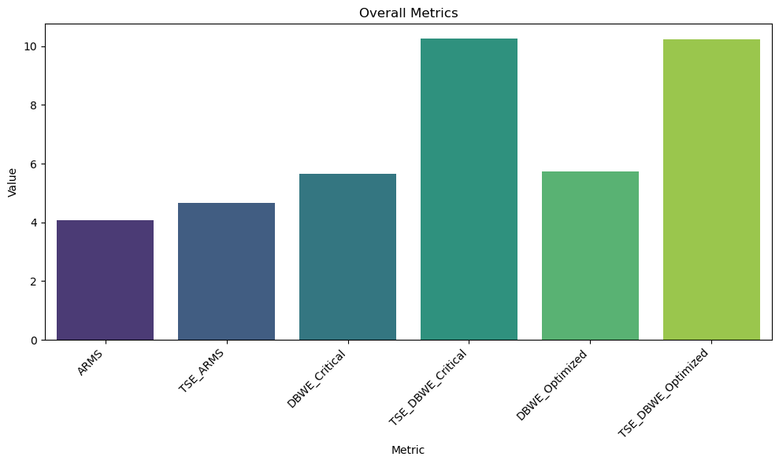

```python
# Bar chart for Overall Metrics
plt.figure(figsize=(10, 6))
sns.barplot(x="Metric", y="Value", data=overall_df, palette="viridis")
plt.title("Overall Metrics")
plt.ylabel("Value")
plt.xlabel("Metric")
plt.xticks(rotation=45, ha="right")
plt.tight_layout()
plt.show()
```

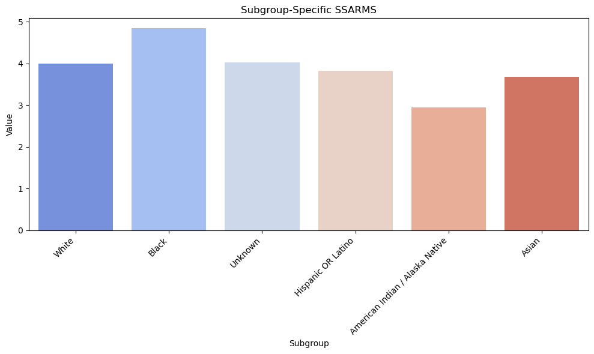

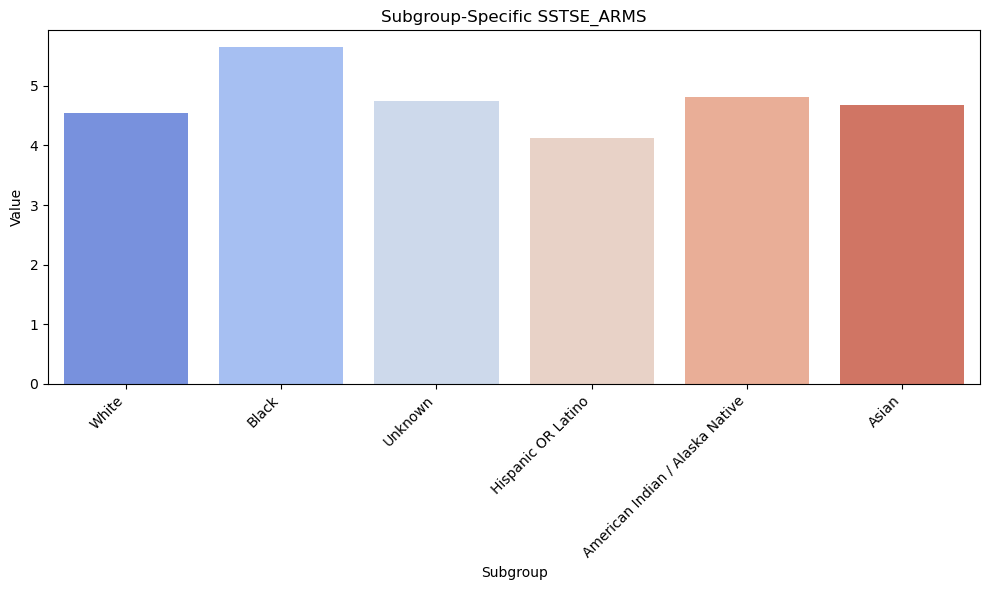

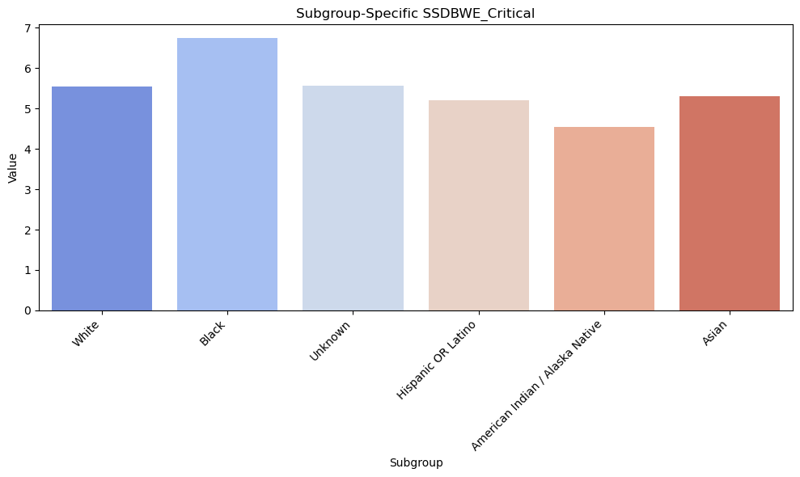

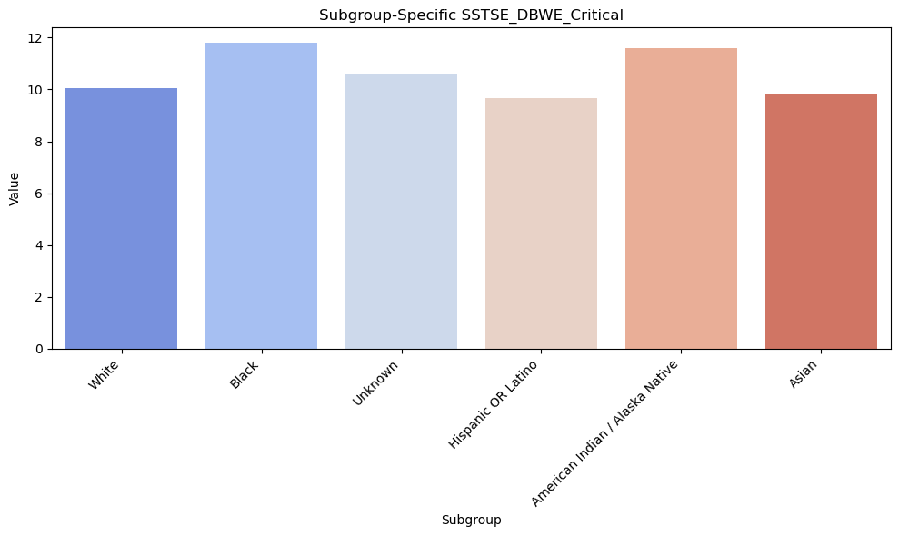

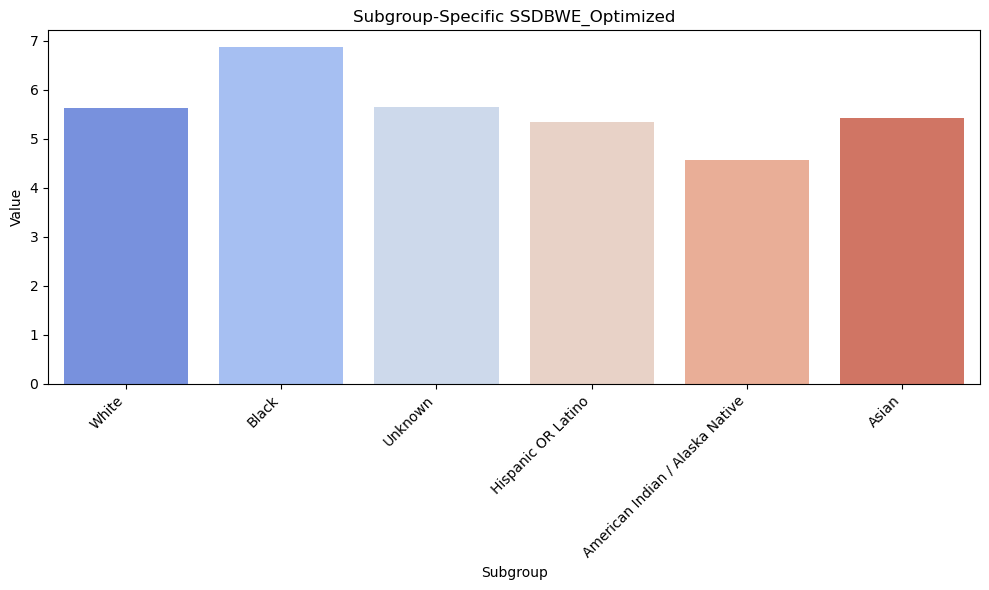

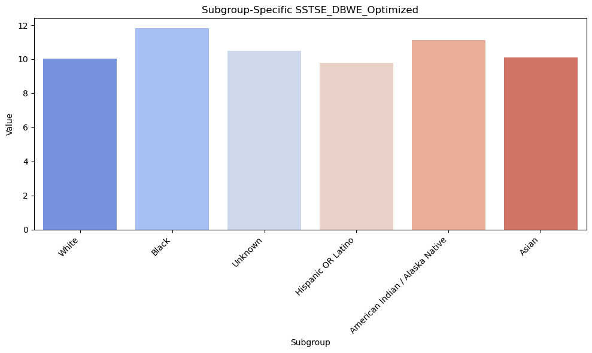

```python
# Bar chart for Subgroup-Specific Metrics
metrics_to_plot = ["SSARMS", "SSTSE_ARMS", "SSDBWE_Critical",
                   "SSTSE_DBWE_Critical", "SSDBWE_Optimized", "SSTSE_DBWE_Optimized"]
for metric in metrics_to_plot:
    plt.figure(figsize=(10, 6))
    sns.barplot(x="Subgroup", y=metric, data=ss_df, palette="coolwarm")
    plt.title(f"Subgroup-Specific {metric}")
    plt.ylabel("Value")
    plt.xlabel("Subgroup")
    plt.xticks(rotation=45, ha="right")
    plt.tight_layout()
    plt.show()
```

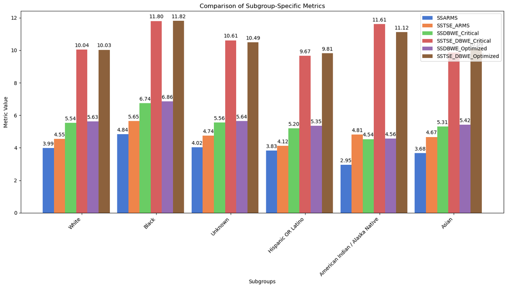

```python
# Grouped bar chart for Subgroup-Specific Metrics
x = np.arange(len(ss_df))  # label locations
width = 0.15  # width of the bars

fig, ax = plt.subplots(figsize=(14, 8))
bars = []
colors = sns.color_palette("muted", n_colors=len(metrics_to_plot))

for i, metric in enumerate(metrics_to_plot):
    bars.append(ax.bar(x + (i - len(metrics_to_plot) / 2) * width,
                       ss_df[metric], width, label=metric, color=colors[i]))

ax.set_title("Comparison of Subgroup-Specific Metrics")
ax.set_xticks(x)
ax.set_xticklabels(ss_df["Subgroup"], rotation=45, ha="right")
ax.set_ylabel("Metric Value")
ax.set_xlabel("Subgroups")
ax.legend()

# Add annotations to bars
for bar_group in bars:
    for bar in bar_group:
        height = bar.get_height()
        if height > 0:
            ax.annotate(f"{height:.2f}",
                        xy=(bar.get_x() + bar.get_width() / 2, height),
                        xytext=(0, 3),  # 3 points vertical offset
                        textcoords="offset points",
                        ha="center", va="bottom")

plt.tight_layout()
plt.show()
```

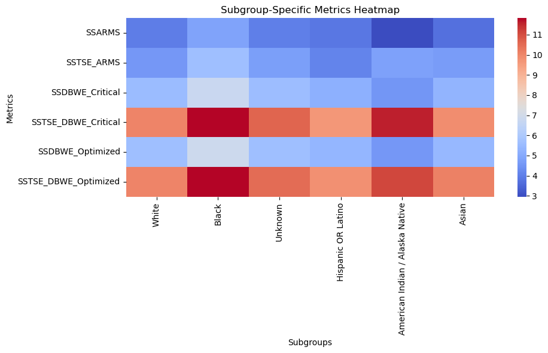

| Subgroup | White | Black | Unknown | Hispanic OR Latino | American Indian / Alaska Native | Asian |
| --- | --- | --- | --- | --- | --- | --- |
| SSARMS | 3.990770 | 4.841466 | 4.022224 | 3.826016 | 2.951916 | 3.681836 |
| SSTSE_ARMS | 4.546394 | 5.648487 | 4.744470 | 4.122970 | 4.810011 | 4.671002 |
| SSDBWE_Critical | 5.541300 | 6.740599 | 5.563483 | 5.196362 | 4.535471 | 5.306835 |
| SSTSE_DBWE_Critical | 10.037944 | 11.797711 | 10.611486 | 9.666150 | 11.606076 | 9.856858 |
| SSDBWE_Optimized | 5.625133 | 6.864767 | 5.639256 | 5.345253 | 4.563291 | 5.417871 |
| SSTSE_DBWE_Optimized | 10.026127 | 11.818512 | 10.487200 | 9.805704 | 11.115050 | 10.091145 |

```python
# Heatmap for Subgroup-Specific Metrics
heatmap_data = ss_df.set_index("Subgroup").T
plt.figure(figsize=(10, 6))
sns.heatmap(heatmap_data, annot=False, fmt=".2f", cmap="coolwarm", cbar=True)
plt.title("Subgroup-Specific Metrics Heatmap")
plt.ylabel("Metrics")
plt.xlabel("Subgroups")
plt.tight_layout()
plt.show()
heatmap_data
```

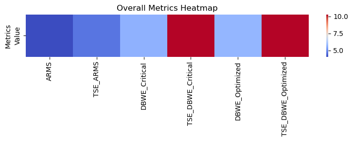

| Metric | ARMS | TSE_ARMS | DBWE_Critical | TSE_DBWE_Critical | DBWE_Optimized | TSE_DBWE_Optimized |
| --- | --- | --- | --- | --- | --- | --- |
| Value | 4.067281 | 4.657172 | 5.648917 | 10.246864 | 5.739127 | 10.235713 |

```python
# Heatmap for Overall Metrics
overall_heatmap_data = overall_df.set_index("Metric").T
plt.figure(figsize=(8, 3))
sns.heatmap(overall_heatmap_data, annot=False, fmt=".2f", cmap="coolwarm", cbar=True)
plt.title("Overall Metrics Heatmap")
plt.ylabel("Metrics")
plt.xlabel("")
plt.tight_layout()
plt.show()
overall_heatmap_data
```